# Results:LR-project.sas

The MEANS Procedure

| Variable | Mean | Std Dev | Minimum | Maximum | Lower Quartile | Median | Upper Quartile | Kurtosis |
| --- | --- | --- | --- | --- | --- | --- | --- | --- |
| life_expectancy adult_mortality | 71.6 152.9 | 8.1 97.6 | 51.0 1.0 | 88.0 484.0 | 65.7 74.0 | 73.9 138.0 | 77.0 215.0 | -0.4 0.2 |

The FREQ Procedure

| Frequency |
| --- |

| Table of life_expectancy_cat by status_bin life_expectancy_cat | Table of life_expectancy_cat by status_bin status_bin 0 | Table of life_expectancy_cat by status_bin status_bin 1 | Table of life_expectancy_cat by status_bin status_bin Total |
| --- | --- | --- | --- |
| 0 | 43 | 0 | 43 |
| 1 | 90 | 6 | 96 |
| 2 | 18 | 26 | 44 |
| Total | 151 | 32 | 183 |

Tabela Y <= 1 vs Y > 1

The FREQ Procedure

| Frequency Col Pct |
| --- |

| Table of life_expectancy_cat by status_bin life_expectancy_cat | Table of life_expectancy_cat by status_bin status_bin 0 | Table of life_expectancy_cat by status_bin status_bin 1 | Table of life_expectancy_cat by status_bin status_bin Total |
| --- | --- | --- | --- |
| 0 | 43 28.48 | 0 0.00 | 43 |
| 3 | 108 71.52 | 32 100.00 | 140 |
| Total | 151 | 32 | 183 |

Statistics for Table of life_expectancy_cat by status_bin

| Odds Ratio and Relative Risks Statistic | Odds Ratio and Relative Risks Value | Odds Ratio and Relative Risks 95% Confidence Limits | Odds Ratio and Relative Risks 95% Confidence Limits |
| --- | --- | --- | --- |
| Relative Risk (Column 1) | 1.2963 | 1.1845 | 1.4186 |

One or more statistics not computed -- zero cell.

Sample Size = 183

Table Y <= 2 vs Y > 2

The FREQ Procedure

| Frequency Col Pct |
| --- |

| Table of life_expectancy_cat by status_bin life_expectancy_cat | Table of life_expectancy_cat by status_bin status_bin 0 | Table of life_expectancy_cat by status_bin status_bin 1 | Table of life_expectancy_cat by status_bin status_bin Total |
| --- | --- | --- | --- |
| 4 | 133 88.08 | 6 18.75 | 139 |
| 2 | 18 11.92 | 26 81.25 | 44 |
| Total | 151 | 32 | 183 |

Statistics for Table of life_expectancy_cat by status_bin

| Odds Ratio and Relative Risks Statistic | Odds Ratio and Relative Risks Value | Odds Ratio and Relative Risks 95% Confidence Limits | Odds Ratio and Relative Risks 95% Confidence Limits |
| --- | --- | --- | --- |
| Odds Ratio | 32.0185 | 11.6032 | 88.3535 |
| Relative Risk (Column 1) | 2.3389 | 1.6369 | 3.3420 |
| Relative Risk (Column 2) | 0.0730 | 0.0322 | 0.1659 |

Sample Size = 183

The LOGISTIC Procedure

| Model Information |  |
| --- | --- |
| Data Set | WORK.D |
| Response Variable | life_expectancy_cat |
| Number of Response Levels | 3 |
| Model | cumulative logit |
| Optimization Technique | Fisher's scoring |

| Number of Observations Read | 183 |
| --- | --- |
| Number of Observations Used | 183 |

| Response Profile Ordered Value | Response Profile life_expectancy_cat | Response Profile Total Frequency |
| --- | --- | --- |
| 1 | 0 | 43 |
| 2 | 1 | 96 |
| 3 | 2 | 44 |

Probabilities modeled are cumulated over the lower Ordered Values.

| Class Level Information Class | Class Level Information Value | Class Level Information Design Variables |
| --- | --- | --- |
| status_bin | 0 | 1 |
|  | 1 | 0 |

| Model Convergence Status |
| --- |
| Convergence criterion (GCONV=1E-8) satisfied. |

| Score Test for the Proportional Odds Assumption Chi-Square | Score Test for the Proportional Odds Assumption DF | Score Test for the Proportional Odds Assumption Pr > ChiSq |
| --- | --- | --- |
| 0.3980 | 1 | 0.5281 |

| Model Fit Statistics Criterion | Model Fit Statistics Intercept Only | Model Fit Statistics Intercept and Covariates |
| --- | --- | --- |
| AIC | 377.845 | 315.421 |
| SC | 384.264 | 325.049 |
| -2 Log L | 373.845 | 309.421 |

| Testing Global Null Hypothesis: BETA=0 Test | Testing Global Null Hypothesis: BETA=0 Chi-Square | Testing Global Null Hypothesis: BETA=0 DF | Testing Global Null Hypothesis: BETA=0 Pr > ChiSq |
| --- | --- | --- | --- |
| Likelihood Ratio | 64.4246 | 1 | <.0001 |
| Score | 53.2901 | 1 | <.0001 |
| Wald | 45.7596 | 1 | <.0001 |

| Type 3 Analysis of Effects Effect | Type 3 Analysis of Effects DF | Type 3 Analysis of Effects Wald Chi-Square | Type 3 Analysis of Effects Pr > ChiSq |
| --- | --- | --- | --- |
| status_bin | 1 | 45.7596 | <.0001 |

| Analysis of Maximum Likelihood Estimates Parameter | Analysis of Maximum Likelihood Estimates | Analysis of Maximum Likelihood Estimates DF | Analysis of Maximum Likelihood Estimates Estimate | Analysis of Maximum Likelihood Estimates Standard Error | Analysis of Maximum Likelihood Estimates Wald Chi-Square | Analysis of Maximum Likelihood Estimates Pr > ChiSq | Analysis of Maximum Likelihood Estimates Exp(Est) |
| --- | --- | --- | --- | --- | --- | --- | --- |
| Intercept | 0 | 1 | -4.4320 | 0.5273 | 70.6428 | <.0001 | 0.012 |
| Intercept | 1 | 1 | -1.4809 | 0.4544 | 10.6195 | 0.0011 | 0.227 |
| status_bin | 0 | 1 | 3.5022 | 0.5177 | 45.7596 | <.0001 | 33.189 |

| Odds Ratio Estimates Effect | Odds Ratio Estimates Point Estimate | Odds Ratio Estimates 95% Wald Confidence Limits | Odds Ratio Estimates 95% Wald Confidence Limits |
| --- | --- | --- | --- |
| status_bin 0 vs 1 | 33.189 | 12.031 | 91.554 |

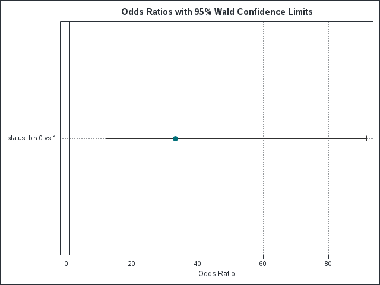

| Association of Predicted Probabilities and Observed Responses |  |  |  |
| --- | --- | --- | --- |
| Percent Concordant | 36.3 | Somers' D | 0.352 |
| Percent Discordant | 1.1 | Gamma | 0.944 |
| Percent Tied | 62.7 | Tau-a | 0.217 |
| Pairs | 10244 | c | 0.676 |

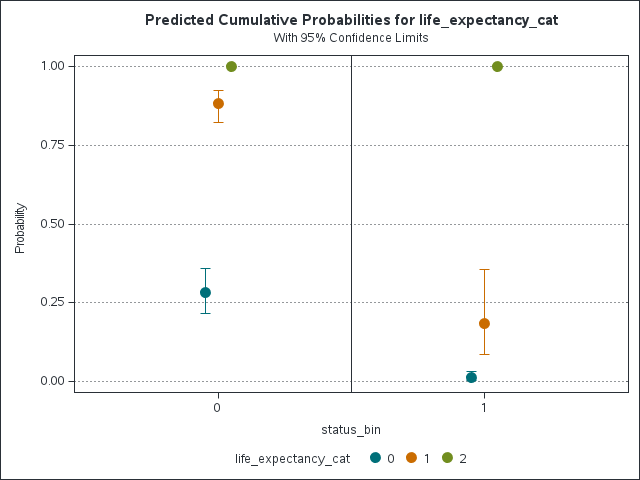

Tabela kontyngencji wszystkie poziomy life_expectancy_cat

The FREQ Procedure

| Frequency |
| --- |

| Table of life_expectancy_cat by adult_mortality_bin life_expectancy_cat | Table of life_expectancy_cat by adult_mortality_bin adult_mortality_bin 0 | Table of life_expectancy_cat by adult_mortality_bin adult_mortality_bin 1 | Table of life_expectancy_cat by adult_mortality_bin adult_mortality_bin Total |
| --- | --- | --- | --- |
| 0 | 7 | 36 | 43 |
| 1 | 39 | 57 | 96 |
| 2 | 43 | 1 | 44 |
| Total | 89 | 94 | 183 |

medium vs low

The FREQ Procedure

| Frequency |
| --- |

| Table of life_expectancy_cat by adult_mortality_bin life_expectancy_cat | Table of life_expectancy_cat by adult_mortality_bin adult_mortality_bin 0 | Table of life_expectancy_cat by adult_mortality_bin adult_mortality_bin 1 | Table of life_expectancy_cat by adult_mortality_bin adult_mortality_bin Total |
| --- | --- | --- | --- |
| 0 | 7 | 36 | 43 |
| 1 | 39 | 57 | 96 |
| Total | 46 | 93 | 139 |

Statistics for Table of life_expectancy_cat by adult_mortality_bin

| Odds Ratio and Relative Risks Statistic | Odds Ratio and Relative Risks Value | Odds Ratio and Relative Risks 95% Confidence Limits | Odds Ratio and Relative Risks 95% Confidence Limits |
| --- | --- | --- | --- |
| Odds Ratio | 0.2842 | 0.1148 | 0.7034 |
| Relative Risk (Column 1) | 0.4007 | 0.1951 | 0.8230 |
| Relative Risk (Column 2) | 1.4100 | 1.1412 | 1.7422 |

Sample Size = 139

high vs low

The FREQ Procedure

| Frequency |
| --- |

| Table of life_expectancy_cat by adult_mortality_bin life_expectancy_cat | Table of life_expectancy_cat by adult_mortality_bin adult_mortality_bin 0 | Table of life_expectancy_cat by adult_mortality_bin adult_mortality_bin 1 | Table of life_expectancy_cat by adult_mortality_bin adult_mortality_bin Total |
| --- | --- | --- | --- |
| 0 | 7 | 36 | 43 |
| 2 | 43 | 1 | 44 |
| Total | 50 | 37 | 87 |

Statistics for Table of life_expectancy_cat by adult_mortality_bin

| Odds Ratio and Relative Risks Statistic | Odds Ratio and Relative Risks Value | Odds Ratio and Relative Risks 95% Confidence Limits | Odds Ratio and Relative Risks 95% Confidence Limits |
| --- | --- | --- | --- |
| Odds Ratio | 0.0045 | 0.0005 | 0.0385 |
| Relative Risk (Column 1) | 0.1666 | 0.0844 | 0.3286 |
| Relative Risk (Column 2) | 36.8372 | 5.2829 | 256.8647 |

Sample Size = 87

Multinomial model - logistic model

The LOGISTIC Procedure

| Model Information |  |
| --- | --- |
| Data Set | WORK.D |
| Response Variable | life_expectancy_cat |
| Number of Response Levels | 3 |
| Model | generalized logit |
| Optimization Technique | Newton-Raphson |

| Number of Observations Read | 183 |
| --- | --- |
| Number of Observations Used | 183 |

| Response Profile Ordered Value | Response Profile life_expectancy_cat | Response Profile Total Frequency |
| --- | --- | --- |
| 1 | 0 | 43 |
| 2 | 1 | 96 |
| 3 | 2 | 44 |

Logits modeled use life_expectancy_cat=2 as the reference category.

| Class Level Information Class | Class Level Information Value | Class Level Information Design Variables |
| --- | --- | --- |
| adult_mortality_bin | 0 | 1 |
|  | 1 | 0 |

| Model Convergence Status |
| --- |
| Convergence criterion (GCONV=1E-8) satisfied. |

| Model Fit Statistics Criterion | Model Fit Statistics Intercept Only | Model Fit Statistics Intercept and Covariates |
| --- | --- | --- |
| AIC | 377.845 | 305.732 |
| SC | 384.264 | 318.570 |
| -2 Log L | 373.845 | 297.732 |

| Testing Global Null Hypothesis: BETA=0 Test | Testing Global Null Hypothesis: BETA=0 Chi-Square | Testing Global Null Hypothesis: BETA=0 DF | Testing Global Null Hypothesis: BETA=0 Pr > ChiSq |
| --- | --- | --- | --- |
| Likelihood Ratio | 76.1135 | 2 | <.0001 |
| Score | 62.9344 | 2 | <.0001 |
| Wald | 25.6631 | 2 | <.0001 |

| Type 3 Analysis of Effects Effect | Type 3 Analysis of Effects DF | Type 3 Analysis of Effects Wald Chi-Square | Type 3 Analysis of Effects Pr > ChiSq |
| --- | --- | --- | --- |
| adult_mortality_bin | 2 | 25.6631 | <.0001 |

| Analysis of Maximum Likelihood Estimates Parameter | Analysis of Maximum Likelihood Estimates | Analysis of Maximum Likelihood Estimates life_expectancy_cat | Analysis of Maximum Likelihood Estimates DF | Analysis of Maximum Likelihood Estimates Estimate | Analysis of Maximum Likelihood Estimates Standard Error | Analysis of Maximum Likelihood Estimates Wald Chi-Square | Analysis of Maximum Likelihood Estimates Pr > ChiSq | Analysis of Maximum Likelihood Estimates Exp(Est) |
| --- | --- | --- | --- | --- | --- | --- | --- | --- |
| Intercept |  | 0 | 1 | 3.5835 | 1.0138 | 12.4946 | 0.0004 | 36.000 |
| Intercept |  | 1 | 1 | 4.0430 | 1.0087 | 16.0645 | <.0001 | 57.000 |
| adult_mortality_bin | 0 | 0 | 1 | -5.3988 | 1.0927 | 24.4136 | <.0001 | 0.005 |
| adult_mortality_bin | 0 | 1 | 1 | -4.1407 | 1.0327 | 16.0772 | <.0001 | 0.016 |

| Odds Ratio Estimates Effect | Odds Ratio Estimates life_expectancy_cat | Odds Ratio Estimates Point Estimate | Odds Ratio Estimates 95% Wald Confidence Limits | Odds Ratio Estimates 95% Wald Confidence Limits |
| --- | --- | --- | --- | --- |
| adult_mortality_bin 0 vs 1 | 0 | 0.005 | <0.001 | 0.038 |
| adult_mortality_bin 0 vs 1 | 1 | 0.016 | 0.002 | 0.120 |

| Parameter Estimates and Wald Confidence Intervals Parameter | Parameter Estimates and Wald Confidence Intervals | Parameter Estimates and Wald Confidence Intervals life_expectancy_cat | Parameter Estimates and Wald Confidence Intervals Estimate | Parameter Estimates and Wald Confidence Intervals 95% Confidence Limits | Parameter Estimates and Wald Confidence Intervals 95% Confidence Limits |
| --- | --- | --- | --- | --- | --- |
| Intercept |  | 0 | 3.5835 | 1.5965 | 5.5705 |
| Intercept |  | 1 | 4.0430 | 2.0660 | 6.0201 |
| adult_mortality_bin | 0 | 0 | -5.3988 | -7.5404 | -3.2572 |
| adult_mortality_bin | 0 | 1 | -4.1407 | -6.1647 | -2.1167 |

Multinomial model - logistic model

The LOGISTIC Procedure

| Model Information |  |
| --- | --- |
| Data Set | WORK.D |
| Response Variable | life_expectancy_cat |
| Number of Response Levels | 3 |
| Model | generalized logit |
| Optimization Technique | Newton-Raphson |

| Number of Observations Read | 183 |
| --- | --- |
| Number of Observations Used | 174 |

| Response Profile Ordered Value | Response Profile life_expectancy_cat | Response Profile Total Frequency |
| --- | --- | --- |
| 1 | 0 | 43 |
| 2 | 1 | 95 |
| 3 | 2 | 36 |

Logits modeled use life_expectancy_cat=2 as the reference category.

Note:9 observations were deleted due to missing values for the response or explanatory variables.

| Model Convergence Status |
| --- |
| Convergence criterion (GCONV=1E-8) satisfied. |

| Model Fit Statistics Criterion | Model Fit Statistics Intercept Only | Model Fit Statistics Intercept and Covariates |
| --- | --- | --- |
| AIC | 352.638 | 326.344 |
| SC | 358.956 | 338.980 |
| -2 Log L | 348.638 | 318.344 |

| Testing Global Null Hypothesis: BETA=0 Test | Testing Global Null Hypothesis: BETA=0 Chi-Square | Testing Global Null Hypothesis: BETA=0 DF | Testing Global Null Hypothesis: BETA=0 Pr > ChiSq |
| --- | --- | --- | --- |
| Likelihood Ratio | 30.2939 | 2 | <.0001 |
| Score | 30.8450 | 2 | <.0001 |
| Wald | 21.2492 | 2 | <.0001 |

| Type 3 Analysis of Effects Effect | Type 3 Analysis of Effects DF | Type 3 Analysis of Effects Wald Chi-Square | Type 3 Analysis of Effects Pr > ChiSq |
| --- | --- | --- | --- |
| hepatitis_b | 2 | 21.2492 | <.0001 |

| Analysis of Maximum Likelihood Estimates Parameter | Analysis of Maximum Likelihood Estimates life_expectancy_cat | Analysis of Maximum Likelihood Estimates DF | Analysis of Maximum Likelihood Estimates Estimate | Analysis of Maximum Likelihood Estimates Standard Error | Analysis of Maximum Likelihood Estimates Wald Chi-Square | Analysis of Maximum Likelihood Estimates Pr > ChiSq |
| --- | --- | --- | --- | --- | --- | --- |
| Intercept | 0 | 1 | 5.7011 | 1.8066 | 9.9581 | 0.0016 |
| Intercept | 1 | 1 | 4.0577 | 1.7884 | 5.1479 | 0.0233 |
| hepatitis_b | 0 | 1 | -0.0655 | 0.0199 | 10.8830 | 0.0010 |
| hepatitis_b | 1 | 1 | -0.0343 | 0.0194 | 3.1288 | 0.0769 |

| Odds Ratio Estimates Effect | Odds Ratio Estimates life_expectancy_cat | Odds Ratio Estimates Point Estimate | Odds Ratio Estimates 95% Wald Confidence Limits | Odds Ratio Estimates 95% Wald Confidence Limits |
| --- | --- | --- | --- | --- |
| hepatitis_b | 0 | 0.937 | 0.901 | 0.974 |
| hepatitis_b | 1 | 0.966 | 0.930 | 1.004 |

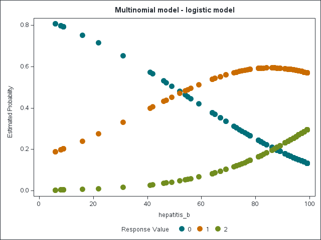